# HW 6

Author

Emujin Batzorig

## Adult Income Dataset

Loading the data from UCI Machine Learning Repository.

```r
library(dplyr)
url <- "https://archive.ics.uci.edu/ml/machine-learning-databases/adult/adult.data"

mydata <- read.csv(url, header = FALSE, na.strings = " ?", stringsAsFactors = FALSE)

colnames(mydata) <- c("age", "workclass", "fnlwgt",  "education", "education-num", "marital-status", "occupation", "relationship", "race", "sex", "capital-gain", "capital-loss","hours-per-week", "native-country", "income")

mydata1 <- mydata %>%
  select(-fnlwgt, -`capital-gain`, -`capital-loss`, `native-country`, -workclass)
head(mydata1)
```

```
  age  education education-num      marital-status         occupation
1  39  Bachelors            13       Never-married       Adm-clerical
2  50  Bachelors            13  Married-civ-spouse    Exec-managerial
3  38    HS-grad             9            Divorced  Handlers-cleaners
4  53       11th             7  Married-civ-spouse  Handlers-cleaners
5  28  Bachelors            13  Married-civ-spouse     Prof-specialty
6  37    Masters            14  Married-civ-spouse    Exec-managerial
    relationship   race     sex hours-per-week native-country income
1  Not-in-family  White    Male             40  United-States  <=50K
2        Husband  White    Male             13  United-States  <=50K
3  Not-in-family  White    Male             40  United-States  <=50K
4        Husband  Black    Male             40  United-States  <=50K
5           Wife  Black  Female             40           Cuba  <=50K
6           Wife  White  Female             40  United-States  <=50K
```

```r
nrow(mydata1)
```

```
[1] 32561
```

```r
ncol(mydata1)
```

```
[1] 11
```

Since mydata has 32561 rows, let’s sample 30 of them to create smaller dataset to work with.

```r
library(dplyr)
set.seed(24)
sample_data <- sample_n(mydata1, 30)
```

```r
library(DT)
datatable(sample_data)
```

|  | age | education | education-num | marital-status | occupation | relationship | race | sex | hours-per-week | native-country | income |
| --- | --- | --- | --- | --- | --- | --- | --- | --- | --- | --- | --- |
| 1 | 27 | Assoc-voc | 11 | Never-married | Craft-repair | Not-in-family | White | Male | 40 | United-States | &lt;=50K |
| 2 | 31 | Bachelors | 13 | Never-married | Prof-specialty | Not-in-family | White | Female | 72 | United-States | &gt;50K |
| 3 | 32 | Bachelors | 13 | Married-civ-spouse | Sales | Husband | White | Male | 45 | United-States | &lt;=50K |
| 4 | 31 | HS-grad | 9 | Never-married | Other-service | Own-child | White | Female | 30 | United-States | &lt;=50K |
| 5 | 41 | Prof-school | 15 | Married-civ-spouse | Prof-specialty | Husband | White | Male | 50 | United-States | &gt;50K |
| 6 | 60 | Some-college | 10 | Married-civ-spouse | Craft-repair | Husband | White | Male | 40 | United-States | &lt;=50K |
| 7 | 42 | Bachelors | 13 | Married-civ-spouse | Prof-specialty | Husband | White | Male | 60 | United-States | &gt;50K |
| 8 | 44 | HS-grad | 9 | Divorced | Adm-clerical | Not-in-family | White | Female | 45 | United-States | &lt;=50K |
| 9 | 18 | 11th | 7 | Never-married | Protective-serv | Own-child | White | Male | 10 | United-States | &lt;=50K |
| 10 | 21 | HS-grad | 9 | Married-civ-spouse | Adm-clerical | Husband | White | Male | 40 | United-States | &lt;=50K |

[output cut: 20 more lines]

## Data Types in this data set

Nominal:

- workclass
- occupation
- marital-status
- race
- Income class (“<=50K”, “>50K”)

Ordinal: education_num

Binary (two categories): sex, income

Ratio: hours-per-week, Age

### Let’s visualize these data types

#### Binary

```r
require(table1)
table1(~ sex + income, data = sample_data)
```

|  | Overall (N=30) |
| --- | --- |
| sex |  |
| Female | 9 (30.0%) |
| Male | 21 (70.0%) |
| income |  |
| <=50K | 22 (73.3%) |
| >50K | 8 (26.7%) |

#### Stratifying

To see if gender affects whether a person earns more than 50K, let’s stratify by gender and compare earnings.

```r
suppressPackageStartupMessages(require(dplyr))
t1 <- mydata1 |>
  group_by(sex) |>
  summarise(
    less_than_50K = mean(income == "<=50K") * 100,
    more_than_50K = mean(income == ">50K") *100
  ) %>%
  as.data.frame()

print(t1)
```

```
      sex less_than_50K more_than_50K
1  Female             0             0
2    Male             0             0
```

Visualizing this:

[figure not shown]

```r
library(ggplot2)

ggplot(t1, aes(x = sex)) +
  geom_bar(aes(y = less_than_50K, fill = "Less than 50K"), stat = "identity", position = position_dodge(width = 0.8)) + geom_bar(aes(y = more_than_50K, fill = "More than 50K"), stat = "identity", position = position_dodge(width = 0.8))+
  labs(x= "Gender", y = "Percentage", fill = "Income Level") +
  ggtitle("Income Distribution by Gender") +
  theme_minimal()
```

#### Diving deeper into variables

Since hours-per-week is not consistent across people, and this may be affecting income, let’s filter the data set and only focus on people who work 40 hours a week.

#### Marital status and Income

Let’s explore whether marital status have a relationship with income.

```r
library(dplyr)
forty_hrs_week_data <- mydata1 %>%
  filter(`hours-per-week` == 40)

t2 <- forty_hrs_week_data %>%
  group_by(`marital-status`, income) %>%
  summarise(count = n()) %>%
  mutate(percentage = count / sum(count) * 100)
tail(t2)
```

```
# A tibble: 6 × 4
# Groups:   marital-status [3]
  `marital-status` income   count percentage
  <chr>            <chr>    <int>      <dbl>
1 " Never-married" " <=50K"  4590      96.4
2 " Never-married" " >50K"    171       3.59
3 " Separated"     " <=50K"   501      95.6
4 " Separated"     " >50K"     23       4.39
5 " Widowed"       " <=50K"   343      91.2
6 " Widowed"       " >50K"     33       8.78
```

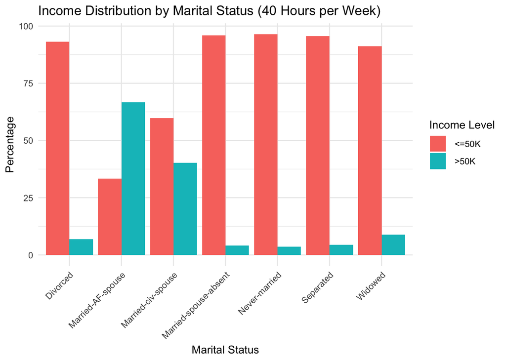

```r
ggplot(t2, aes(x = `marital-status`, y = percentage, fill = income)) +
  geom_bar(stat = "identity", position = "dodge") +
  labs(x = "Marital Status", y = "Percentage", fill = "Income Level") +
  ggtitle("Income Distribution by Marital Status (40 Hours per Week)") +
  theme_minimal() +
  theme(axis.text.x = element_text(angle = 45, hjust = 1))
```

#### Education_num and Income

```r
library(dplyr)
library(ggplot2)

t3 <- forty_hrs_week_data %>%
  group_by(`education-num`, income)%>%
  summarise(count = n()) %>%
  mutate(percentage = count / sum(count) *100)
head(t3)
```

```
# A tibble: 6 × 4
# Groups:   education-num [4]
  `education-num` income   count percentage
            <int> <chr>    <int>      <dbl>
1               1 " <=50K"    25     100
2               2 " <=50K"    77      96.2
3               2 " >50K"      3       3.75
4               3 " <=50K"   192      95.0
5               3 " >50K"     10       4.95
6               4 " <=50K"   297      94.3
```

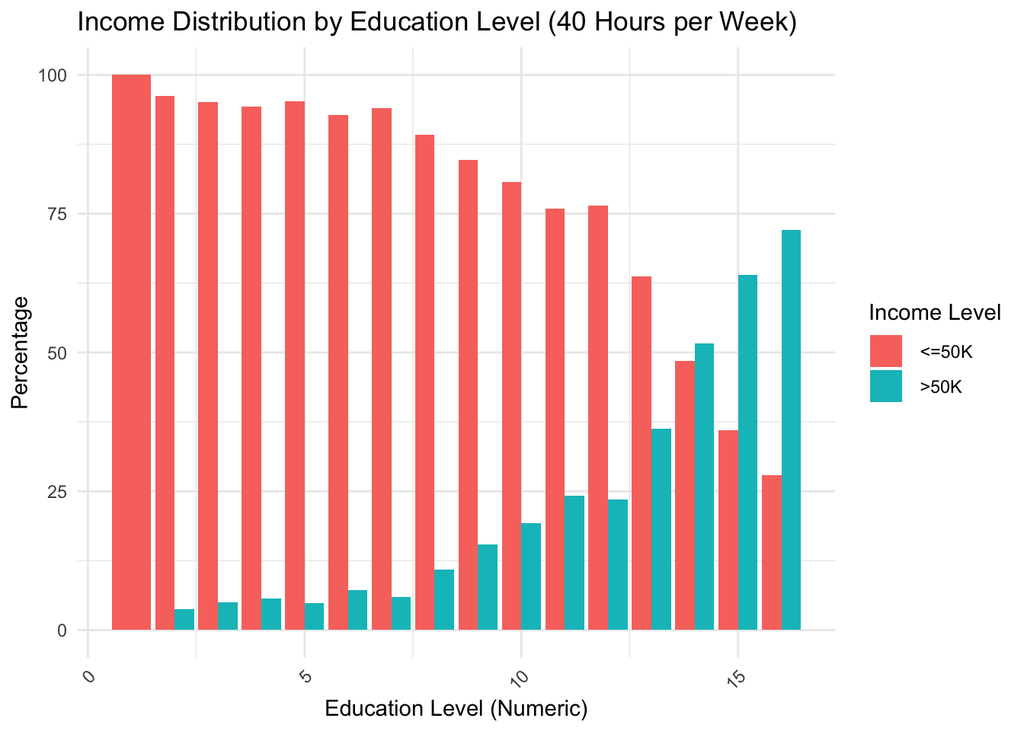

```r
ggplot(t3, aes(x = `education-num`, y = percentage, fill = income)) +
  geom_bar(stat = "identity", position = "dodge") +
  labs(x = "Education Level (Numeric)", y = "Percentage", fill = "Income Level") +
  ggtitle("Income Distribution by Education Level (40 Hours per Week)") +
  theme_minimal() +
  theme(axis.text.x = element_text(angle = 45, hjust = 1))
```

result: We can see that as education level (education_num score) increases, the % of people who >50K is increasing. There is a strong correlation between income level and education level.

Summarizing data types and visualization:

Because the variables we compared were categorical, we created bar plots. But, now let’s explore continuous variable and create histograms.

#### Age and Income

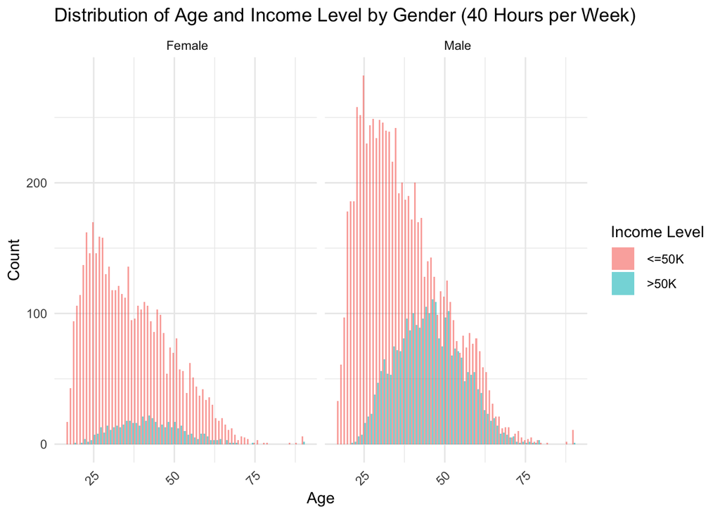

```r
library(dplyr)
library(ggplot2)

ggplot(forty_hrs_week_data, aes(x = age, fill = income)) +
  geom_histogram(binwidth = 1, position = "dodge", alpha = 0.6) +
  facet_wrap(~ sex) +
  labs(x = "Age", y = "Count", fill = "Income Level") +
  ggtitle("Distribution of Age and Income Level by Gender (40 Hours per Week)") +
  theme_minimal() +
  theme(axis.text.x = element_text(angle = 45, hjust = 1))
```

### Conclusion

We analyzed public data set called adult.data and cleaned to perform analysis. We stratified by several variables to identify relationships between them, specifically relationship with income level. We also paid attention to what visualization to use on what type of data and were able to answer our questions.